# ESM_201_A_2

1a)

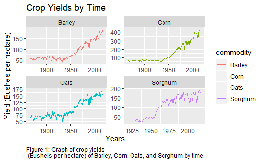

[output not shown]

#1b) According to the graphs, it looks as if Barley, Oats, and Corn are Linear, Lower Plateau(LLP). However, Sorghum looks like it could be Linear, upper plateau(LUP) or maybe even Linear piecewise (PW) statistic model.

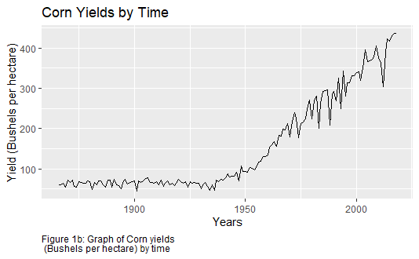

[output not shown]

#2a)

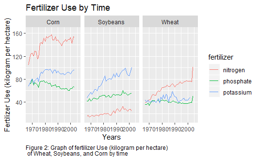

[output not shown]

2b) Observations: Corn and Wheat have more Nitrogen fertilizer than the other fertilizers. Additionally, Corn has significantly more nitrogen use than any of the other two crops. Soybeans has more potassium than nitrogen and phosphate.

For Corn, the limiting nutrient is Nitrogen because it is needed the most for the yields to grow. For Soybeans, the limiting nutrient is Potassium. For Wheat, the limiting nutrient is Nitrogen as well.

3a)

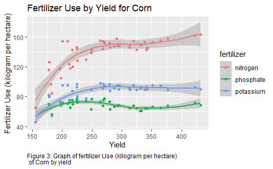

[output not shown]

The relationship is not linear. Although it does yield does increase in the beginning as you add fertilizer, it tapers out. It no longer provides high yields when you add more fertilizer.